# Spotify Data

Lucia Kajanová, Lukáš Poledňa, Tereza Slaninová, Kateřina Válková

12. 12. 2023

# Introduction

## Data

- Most Streamed Spotify Songs 2023
- Kaggle — Nidula Elgiriyewithana
- numeric variable — streams

## Description of variables

- PLAYLISTS – appearance of songs in different platforms’ playlists
- CHARTS – appearance of songs in different platforms’ charts
- MUSICAL ATTRIBUTES – beats per minute, key and mode of the song
- ARTIST INFORMATION – name of artist(s), number of artists contributing to songs
- SONG INFORMATION – track name, day, month and year of release
- OTHERS – danceability, acousticness, liveness, …

## Summary

```r
summary(spotify_data)
```

```
##   track_name        artists_name        artist_count   released_year
##  Length:829         Length:829         Min.   :1.000   Min.   :1930
##  Class :character   Class :character   1st Qu.:1.000   1st Qu.:2021
##  Mode  :character   Mode  :character   Median :1.000   Median :2022
##                                        Mean   :1.581   Mean   :2019
##                                        3rd Qu.:2.000   3rd Qu.:2022
##                                        Max.   :8.000   Max.   :2023
##  released_month    released_day   in_spotify_playlists in_spotify_charts
##  Min.   : 1.000   Min.   : 1.00   Min.   :   31        Min.   :  0.00
##  1st Qu.: 3.000   1st Qu.: 6.00   1st Qu.:  801        1st Qu.:  0.00
##  Median : 6.000   Median :13.00   Median : 1788        Median :  2.00
##  Mean   : 6.154   Mean   :14.11   Mean   : 3116        Mean   : 10.82
##  3rd Qu.: 9.000   3rd Qu.:22.00   3rd Qu.: 3879        3rd Qu.: 15.00
##  Max.   :12.000   Max.   :31.00   Max.   :29499        Max.   :147.00
##     streams          in_apple_playlists in_apple_charts  in_deezer_playlists
##  Min.   :2.762e+03   Min.   :  0.00     Min.   :  0.00   Min.   :  0.00
##  1st Qu.:1.304e+08   1st Qu.: 11.00     1st Qu.:  6.00   1st Qu.: 12.00
##  Median :2.451e+08   Median : 27.00     Median : 30.00   Median : 32.00
##  Mean   :3.738e+08   Mean   : 49.69     Mean   : 47.15   Mean   : 96.75
##  3rd Qu.:4.817e+08   3rd Qu.: 68.00     3rd Qu.: 80.00   3rd Qu.: 99.00
##  Max.   :2.808e+09   Max.   :492.00     Max.   :275.00   Max.   :974.00
##  in_deezer_charts in_shazam_charts      bpm          key
##  Min.   : 0.000   Min.   :  0.00   Min.   : 65   Length:829
##  1st Qu.: 0.000   1st Qu.:  0.00   1st Qu.:100   Class :character
##  Median : 0.000   Median :  2.00   Median :121   Mode  :character
##  Mean   : 2.341   Mean   : 48.71   Mean   :123
##  3rd Qu.: 1.000   3rd Qu.: 33.00   3rd Qu.:142
##  Max.   :45.000   Max.   :953.00   Max.   :206
##      mode            danceability     valence          energy
##  Length:829         Min.   :23.0   Min.   : 4.00   Min.   :14.00
##  Class :character   1st Qu.:58.0   1st Qu.:32.00   1st Qu.:53.00
##  Mode  :character   Median :70.0   Median :51.00   Median :65.00
##                     Mean   :67.4   Mean   :51.37   Mean   :64.24
##                     3rd Qu.:78.0   3rd Qu.:70.00   3rd Qu.:77.00
##                     Max.   :96.0   Max.   :97.00   Max.   :97.00
##   acousticness   instrumentalness    liveness      speechiness
##  Min.   : 0.00   Min.   : 0.000   Min.   : 3.00   Min.   : 2.00
##  1st Qu.: 6.00   1st Qu.: 0.000   1st Qu.:10.00   1st Qu.: 4.00
##  Median :18.00   Median : 0.000   Median :12.00   Median : 6.00
##  Mean   :27.07   Mean   : 1.654   Mean   :18.33   Mean   :10.43
##  3rd Qu.:42.00   3rd Qu.: 0.000   3rd Qu.:23.00   3rd Qu.:12.00
##  Max.   :97.00   Max.   :91.000   Max.   :97.00   Max.   :64.00
```

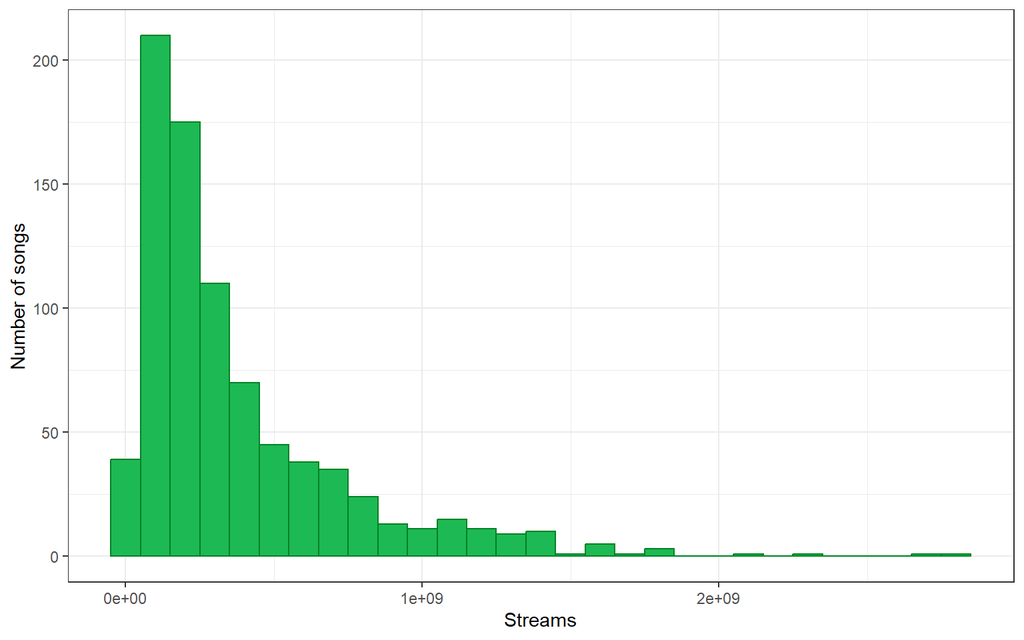

```r
p <- ggplot(spotify_data, aes(x = streams)) +
        geom_histogram(binwidth = 100000000, fill = "#1DB954", color = "#008222", alpha = 1000) +
        xlab("Streams") +
        ylab("Number of songs") +
        theme(plot.title = element_text(size = 15)) +
        theme_bw()
print(p)
```

## Correlation matrix

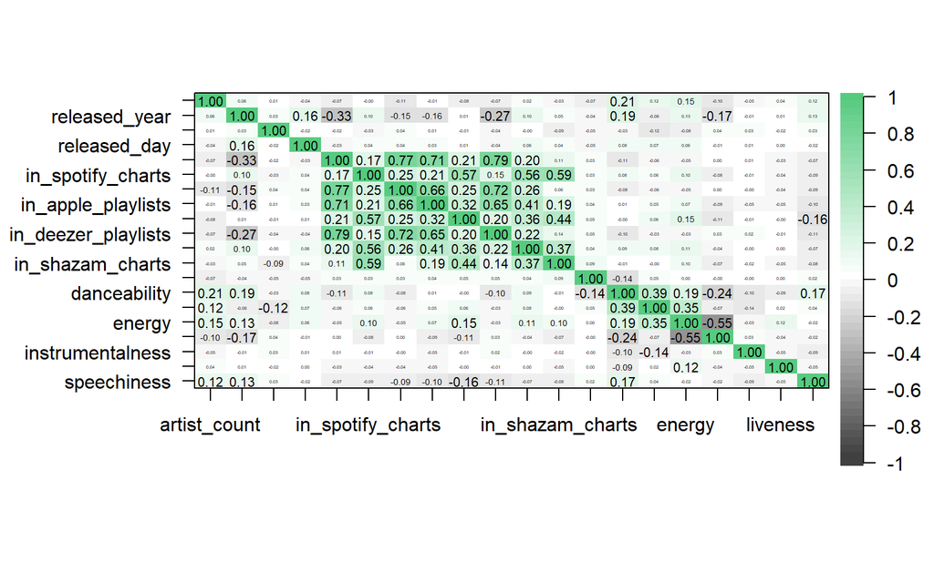

```r
numeric <- spotify_data %>% select_if(is.numeric)
gr <- colorRampPalette(c("black", "white", "#1DB954"))
corPlot(numeric, gr = gr, main = "")
```

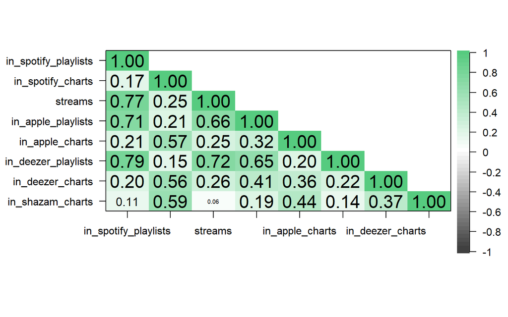

```r
gr2 <- colorRampPalette(c("black", "white", "#1DB954"))
corPlot(numeric[, 5:12], gr = gr2, main = "", upper = FALSE)
```

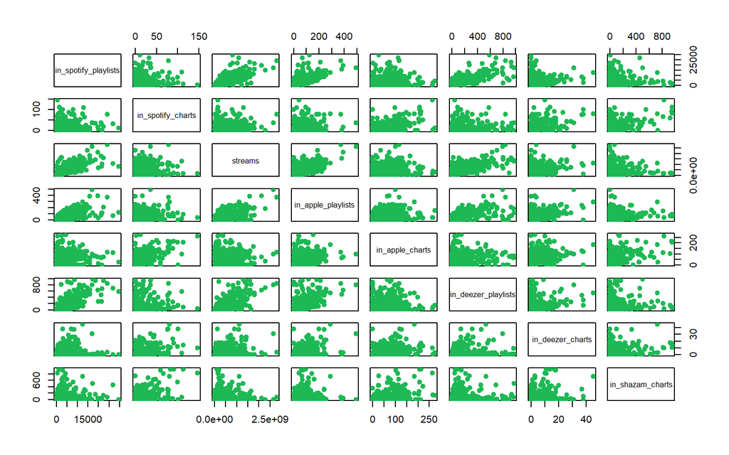

```r
pairs(spotify_data[, c(7, 8, 9, 10, 11, 12, 13, 14)], col="#1DB954", pch=19)
```

## SPOTIFY/APPLE/DEEZER PLAYLISTS

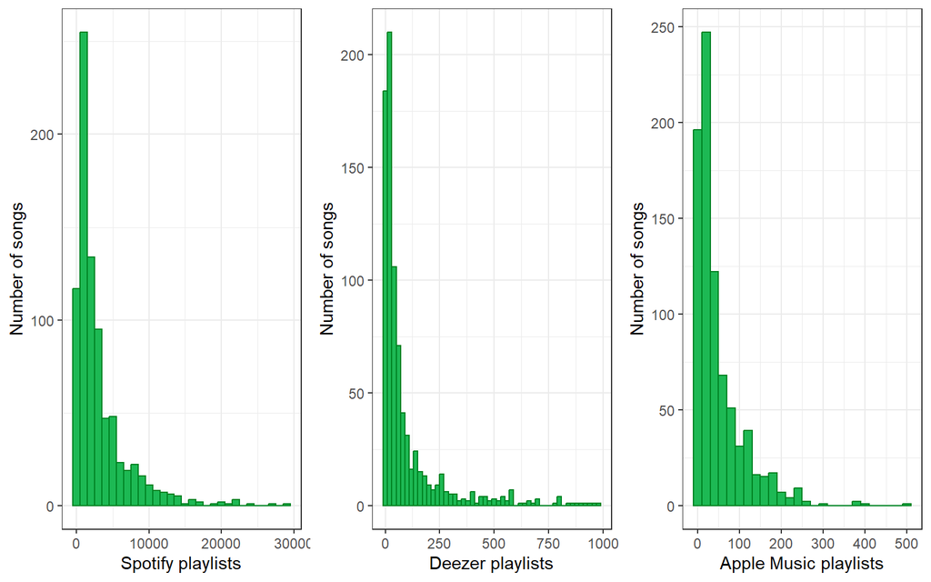

```r
# Spotify
p11 <- ggplot(spotify_data, aes(x = in_spotify_playlists)) +
  geom_histogram(binwidth = 1000, fill = "#1DB954", color = "#008222", alpha = 1000) +
  xlab("Spotify playlists") +
  ylab("Number of songs") +
  theme(plot.title = element_text(size = 15)) +
  theme_bw()


# Apple
p33 <- ggplot(spotify_data, aes(x = in_apple_playlists)) +
  geom_histogram(binwidth = 20, fill = "#1DB954", color = "#008222", alpha = 1000) +
  xlab("Apple Music playlists") +
  ylab("Number of songs") +
  theme(plot.title = element_text(size = 15)) +
  theme_bw()


# Deezer
p22 <- ggplot(spotify_data, aes(x = in_deezer_playlists)) +
  geom_histogram(binwidth = 20, fill = "#1DB954", color = "#008222", alpha = 1000) +
  xlab("Deezer playlists") +
  ylab("Number of songs") +
  theme(plot.title = element_text(size = 15)) +
  theme_bw()

p <- plot_grid(p11, p22, p33,
               ncol = 3, nrow = 1)
print(p)
```

## SPOTIFY/APPLE/DEEZER CHARTS

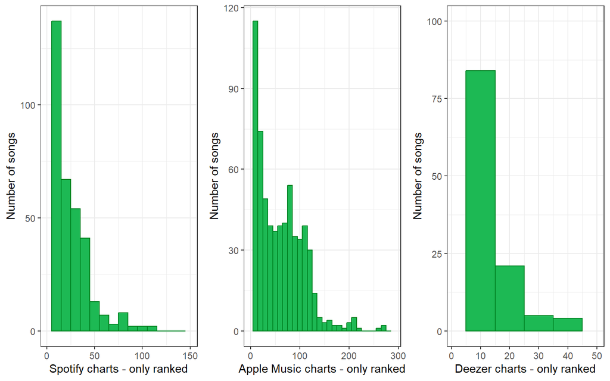

```r
# Spotify
p4 <- ggplot(spotify_data, aes(x = in_spotify_charts)) +
  geom_histogram(binwidth = 10, fill = "#1DB954", color = "#008222", alpha = 1000) +
  xlim(1, 150) +
  xlab("Spotify charts - only ranked") +
  ylab("Number of songs") +
  theme(plot.title = element_text(size = 15)) +
  theme_bw()


# Apple
p6 <- ggplot(spotify_data, aes(x = in_apple_charts)) +
  geom_histogram(binwidth = 10, fill = "#1DB954", color = "#008222", alpha = 1000) +
  xlim(1, 290) +
  xlab("Apple Music charts - only ranked") +
  ylab("Number of songs") +
  theme(plot.title = element_text(size = 15)) +
  theme_bw()


# Deezer
p5 <- ggplot(spotify_data, aes(x = in_deezer_charts)) +
  geom_histogram(binwidth = 10, fill = "#1DB954", color = "#008222", alpha = 1000) +
  xlim(1, 50) +
  ylim(0, 100) +
  xlab("Deezer charts - only ranked") +
  ylab("Number of songs") +
  theme(plot.title = element_text(size = 15)) +
  theme_bw()

p <- plot_grid(p4, p6, p5,
               ncol = 3, nrow = 1)
print(p)
```

## ARTISTS

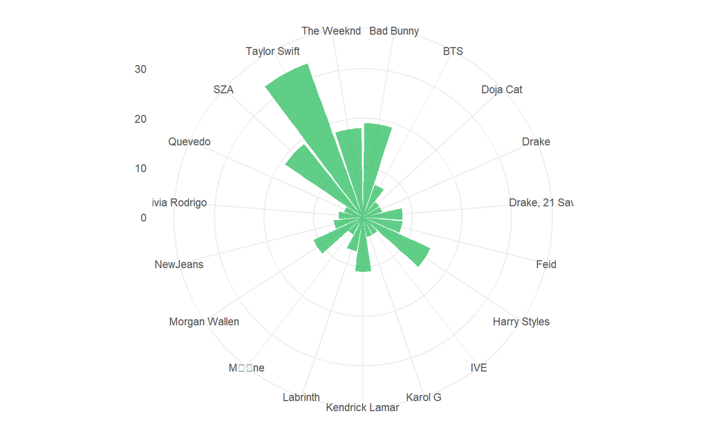

# Model selection

## MODELS

- Model 3A: $Streams_i = \beta_0 + \beta_1 \times Sch + \beta_2 \times Ach + \beta_3 \times Dch + \\ \beta_4 \times (Sch \times Ach)_i + \beta_5 \times (Ach \times Dch)_i + \\ \beta_6 \times (Sch \times Dch)_i + \beta_7 \times (Sch \times Dch \times Ach)_i + \epsilon_i$
- Model 3B: $Streams_i = \beta_0 + \beta_1 \times Sch + \beta_2 \times Ach + \beta_3 \times Dch \\+ \beta_4 \times Sp + \beta_5 \times Ap + \beta_6 \times Dp + \beta_7 \times (Sp \times Sch)_i \\+ \beta_8 \times (Ap \times Ach)_i + \beta_9 \times (Dch \times Dp)_i + \epsilon_i$
- Model 6: $Streams_i = \beta_0 + \beta_1 \times Sp + \beta_2 \times Ap + \beta_3 \times Dp \\+ \beta_4 \times (Sp \times Ap)_i + \beta_5 \times (Ap \times Dp)_i + \beta_6 \times (Sp \times Dp)_i \\+ \beta_7 \times (Sp \times Dp \times Ap)_i + \epsilon_i$
- Model 8: $Streams_i = \beta_0 + \beta_1 \times Sch + \beta_2 \times Ach + \beta_3 \times Dch \\+ \beta_4 \times Sp + \beta_5 \times Ap + \beta_6 \times Dp + \beta_7 \times (Sp \times Sch)_i + \\ \beta_8 \times (Ap \times Ach)_i + \beta_9 \times (Dch \times Dp)_i +\\ \beta_{10} \times (Sp \times Ap)_i + \beta_{11} \times (Ap \times Dp)_i \\+ \beta_{12} \times (Sp \times Dp)_i + \beta_{13} \times (Sp \times Dp \times Ap)_i + \epsilon_i$
- Model 9: $Streams_i = \beta_0 + \beta_1 \times Sch + \beta_2 \times Ach \\ + \beta_3 \times Sp + \beta_4 \times Ap + \beta_5 \times Dp \\ + \beta_6 \times (Sp \times Dp)_i + \beta_7 \times (Sp \times Ap)_i + \\ \beta_8 \times (Dp \times Ap)_i + \beta_9 \times (Ap \times Ach)_i + \beta_{10} \times (Sp \times Sch)_i + \\ \beta_{11} \times (Sp \times Dp \times Ap)_i+ \epsilon_i$
- Model 11: $Streams_i = \beta_0 + \beta_1 \times Sch + \beta_2 \times Sp + \beta_3 \times Ap + \\ \beta_4 \times Dp + \beta_5 \times (Sp \times Dp)_i + \\ \beta_6 \times (Sp \times Ap)_i + \beta_7 \times (Dp \times Ap)_i \\+ \beta_8 \times (Sp \times Sch)_i + \beta_9 \times (Sp \times Dp \times Ap)_i + \epsilon_i$

```
##                      Model 3A   Model 3B    Model 6    Model 8    Model 9
## Adjusted R squared     0.1325     0.6513     0.6776     0.6921     0.6922
## AIC                34954.9460 34201.3053 34134.3751 34102.1575 34100.0361
## BIC                34997.4280 34253.2277 34176.8571 34172.9608 34161.3989
##                      Model 11
## Adjusted R squared     0.6922
## AIC                34097.8601
## BIC                34149.7826
```

## MODEL 9

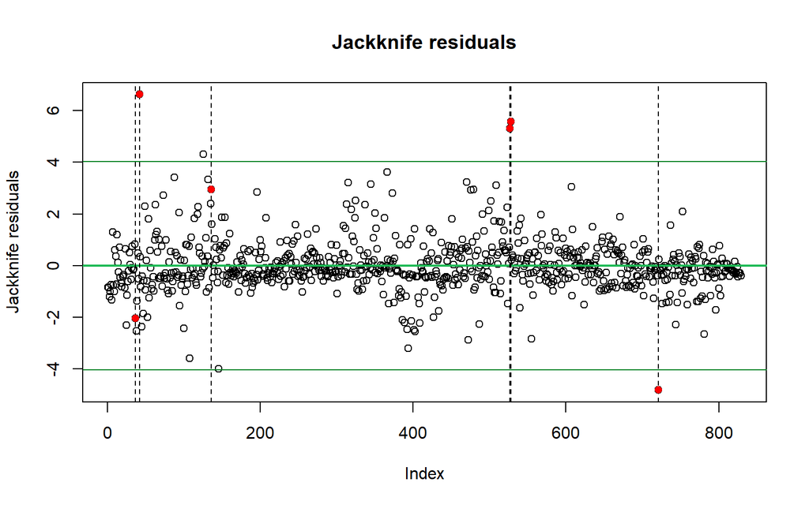

## MODEL 11

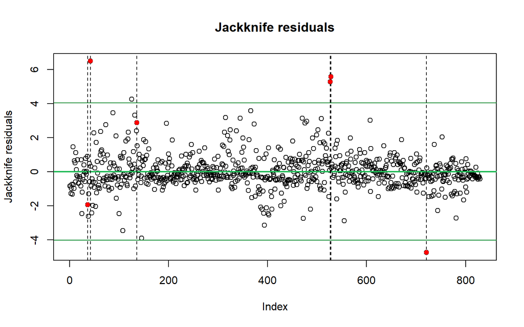

```
##                     Model 9_1 Model 11_1
## Adjusted R squared     0.7233     0.7221
## AIC                33806.1194 33807.8747
## BIC                33867.4194 33859.7440
```

# Model 9

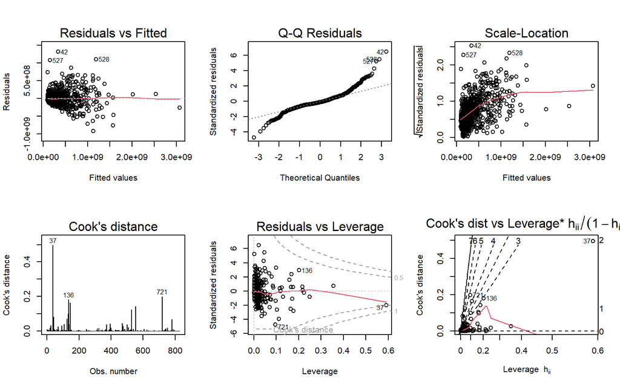

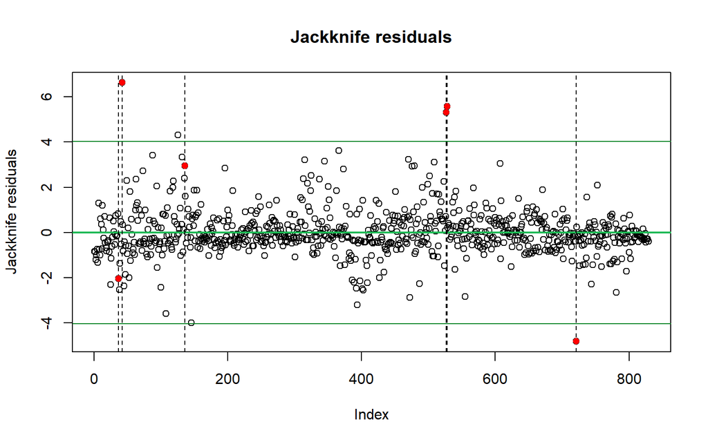

## MODEL 9_1

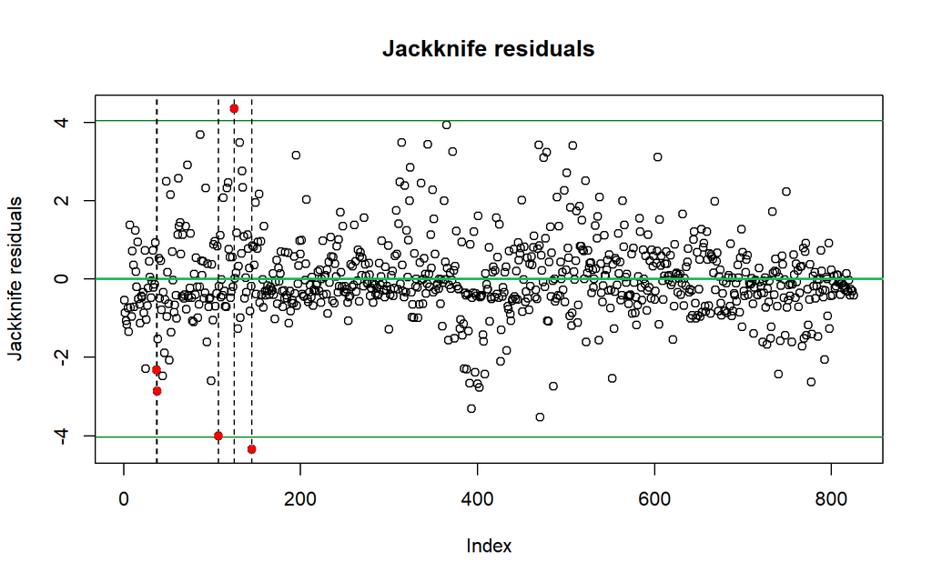

## MODELS 9, 9_1, 9_2

[output not shown]

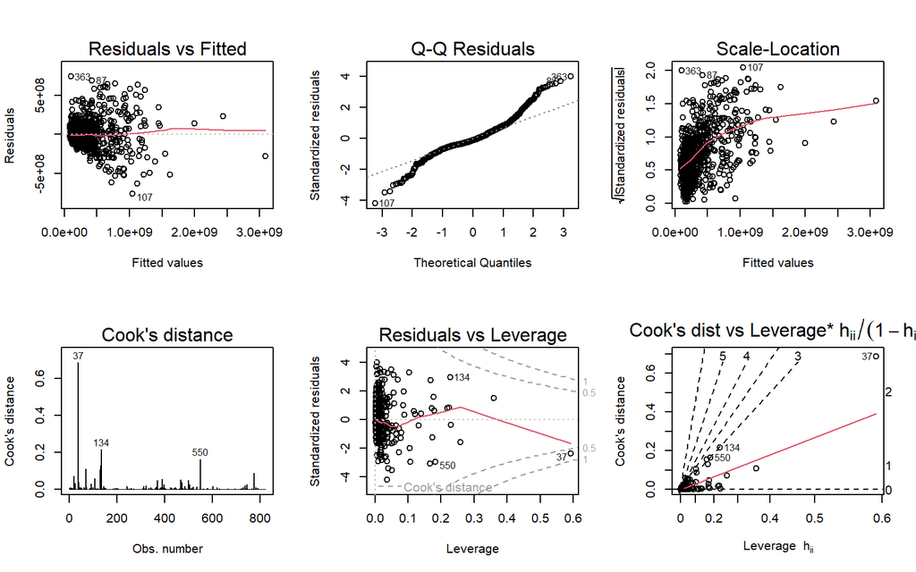

# Prediction intervals

## MODEL 1

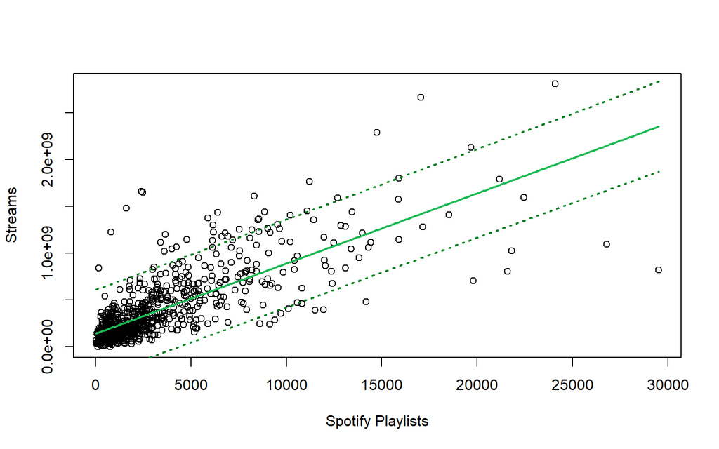

## MODEL 2

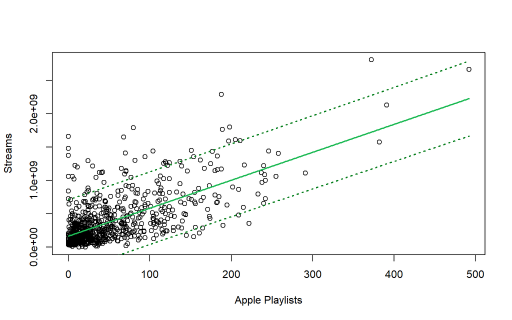

# Confidence intervals

## MODEL 1

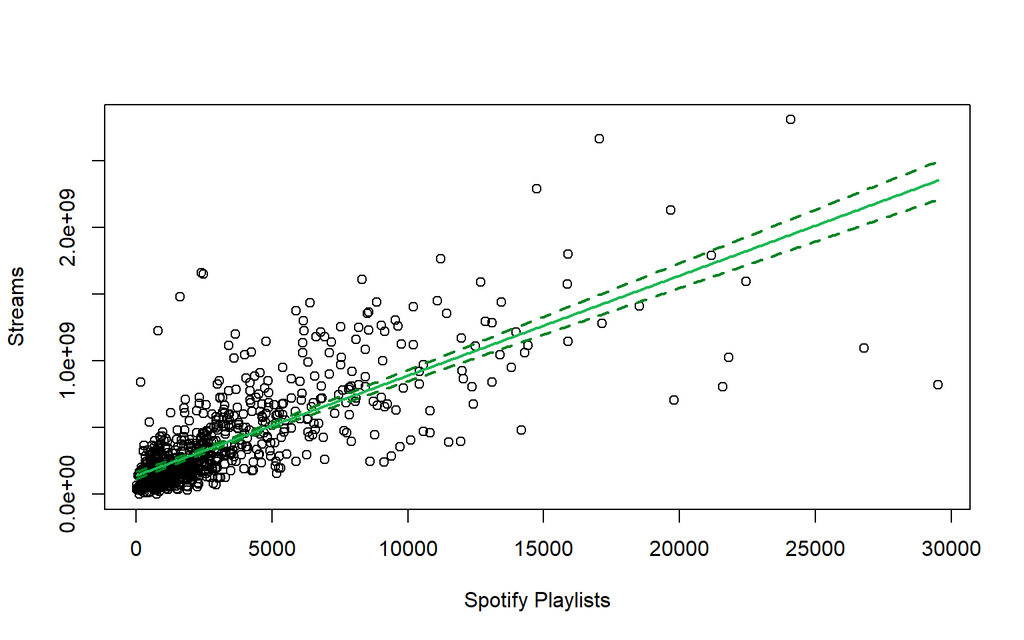

## MODEL 2

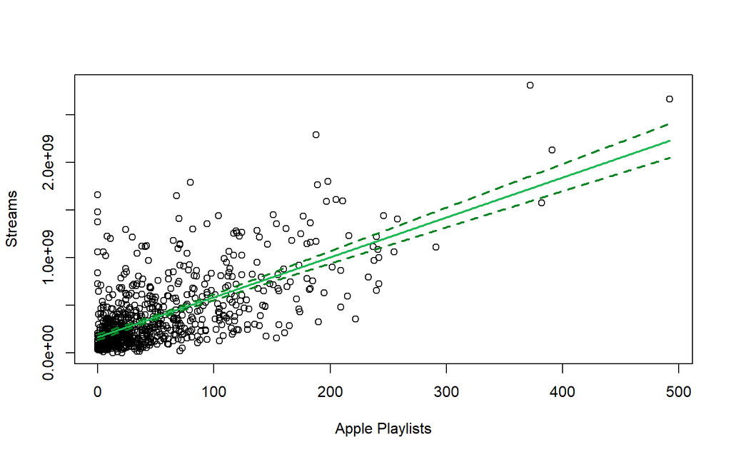

# Thank you for your attention